# STATS-PRELIM-EXPLORATION

# 1 Overview

For these exploratory runs there were 50 objectives to optimize, all with the target of 100 and an accuracy requirement of 99%. The population was size 512, and there was a point mutation probability of .7% at each objective.

# 2 Mu Lambda Selection

## 2.1 Maximum Aggregate Performance Data

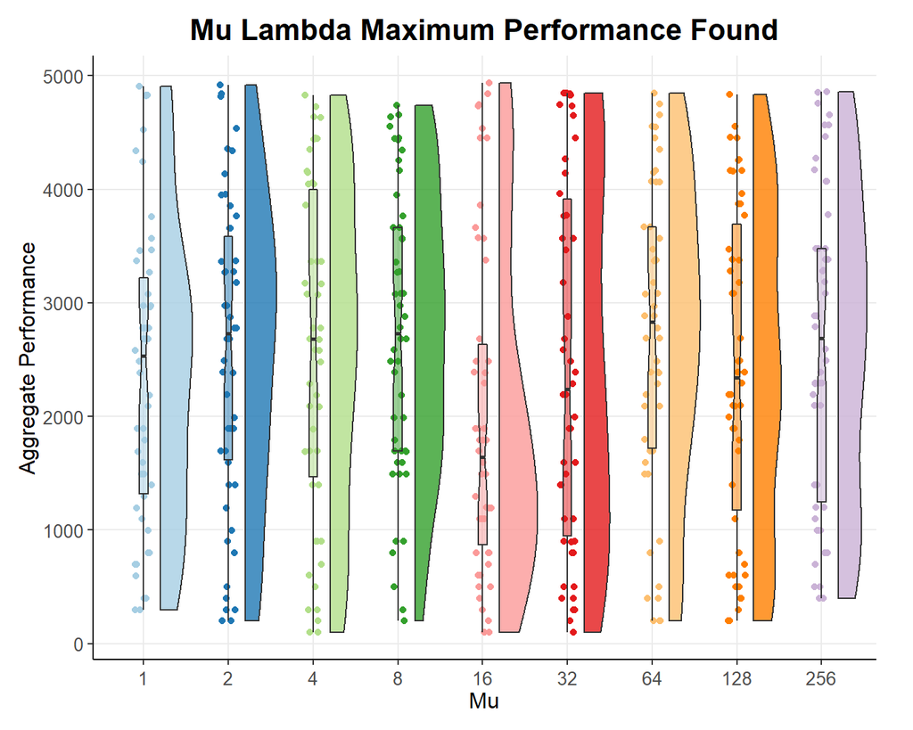

### 2.1.1 Summary Statistics

```r
# GET STATS BETWEEN EACH Mu
do.call("rbind", tapply(max_perf$val, max_perf$Mu, summary))
```

```
##        Min.   1st Qu.   Median     Mean  3rd Qu.    Max.
## 1   299.910 1321.3875 2533.745 2382.543 3222.493 4904.69
## 2   199.989 1619.7075 2730.295 2564.506 3583.963 4918.72
## 4   100.000 1470.0650 2680.295 2581.584 4000.065 4826.47
## 8   199.988 1694.8775 2732.130 2718.959 3662.608 4736.50
## 16  100.000  873.8708 1644.720 1991.322 2632.050 4935.99
## 32  100.000  949.0602 2241.315 2469.393 3913.925 4845.73
## 64  199.988 1721.1525 2832.220 2702.217 3668.300 4849.92
## 128 199.991 1173.3675 2340.540 2412.205 3694.785 4837.81
## 256 399.848 1248.9300 2689.025 2631.256 3478.847 4858.98
```

### 2.1.2 Stats Tests

The Kuskal-Wallis test show evidence of no statisticaly significant differences between Mu values.

```r
kruskal.test(val ~ Mu, data = max_perf)
```

```
##
##  Kruskal-Wallis rank sum test
##
## data:  val by Mu
## Kruskal-Wallis chi-squared = 10.349, df = 8, p-value = 0.2413
```

The pairwaise Wilcoxon rank sum tests show evidence of no statisticaly significant differences between Mu values.

```r
pairwise.wilcox.test(x = max_perf$val, g = max_perf$Mu, p.adjust.method = "BH", paired = FALSE, conf.int = TRUE, conf.level = .95, alternative = 't')
```

```
##
##  Pairwise comparisons using Wilcoxon rank sum test
##
## data:  max_perf$val and max_perf$Mu
##
##     1    2    4    8    16   32   64   128
## 2   0.94 -    -    -    -    -    -    -
## 4   0.94 0.96 -    -    -    -    -    -
## 8   0.71 0.94 0.94 -    -    -    -    -
## 16  0.61 0.29 0.36 0.18 -    -    -    -
## 32  0.94 0.94 0.94 0.94 0.61 -    -    -
## 64  0.72 0.94 0.94 0.94 0.18 0.94 -    -
## 128 0.94 0.94 0.94 0.93 0.61 0.94 0.93 -
## 256 0.92 0.94 0.94 0.94 0.29 0.94 0.94 0.92
##
## P value adjustment method: BH
```

## 2.2 Maximum Optimal Objective Count Data

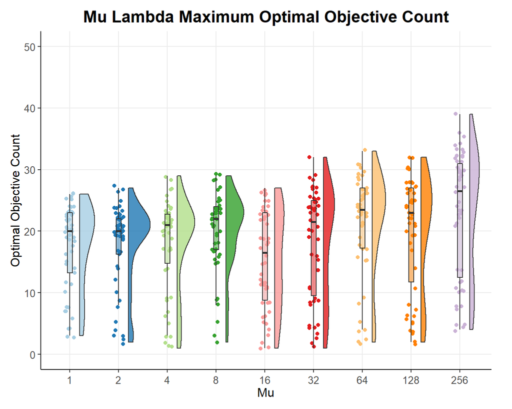

### 2.2.1 Summary Statistics

```r
# GET STATS BETWEEN EACH Mu
do.call("rbind", tapply(max_opti$val, max_opti$Mu, summary))
```

```
##     Min. 1st Qu. Median  Mean 3rd Qu. Max.
## 1      3   13.25   20.0 17.52   23.00   26
## 2      2   16.25   20.0 17.96   22.00   27
## 4      1   14.75   21.0 17.90   22.75   29
## 8      2   17.00   22.0 20.00   24.00   29
## 16     1    8.75   16.5 15.52   23.00   27
## 32     1    9.50   21.5 18.06   25.00   32
## 64     2   17.25   23.5 21.18   27.00   33
## 128    2   11.75   23.0 19.62   27.00   32
## 256    4   12.50   26.5 23.02   31.00   39
```

### 2.2.2 Stats Tests

The Kuskal-Wallis test show evidence of statisticaly significant differences between Mu values.

```r
kruskal.test(val ~ Mu, data = max_opti)
```

```
##
##  Kruskal-Wallis rank sum test
##
## data:  val by Mu
## Kruskal-Wallis chi-squared = 37.725, df = 8, p-value = 8.464e-06
```

The pairwaise Wilcoxon rank sum tests show evidence that Mu=256 is statsically greater than all other Mu values (Except 64).

```r
pairwise.wilcox.test(x = max_opti$val, g = max_opti$Mu, p.adjust.method = "BH", paired = FALSE, conf.int = TRUE, conf.level = .95, alternative = 'g')
```

```
##
##  Pairwise comparisons using Wilcoxon rank sum test
##
## data:  max_opti$val and max_opti$Mu
##
##     1      2      4      8      16     32     64     128
## 2   0.5144 -      -      -      -      -      -      -
## 4   0.4443 0.4706 -      -      -      -      -      -
## 8   0.0656 0.0701 0.1028 -      -      -      -      -
## 16  0.9335 0.9335 0.9335 0.9963 -      -      -      -
## 32  0.2037 0.2209 0.2781 0.7819 0.0782 -      -      -
## 64  0.0049 0.0050 0.0089 0.0782 0.0019 0.0701 -      -
## 128 0.0427 0.0427 0.0662 0.2781 0.0170 0.2123 0.8282 -
## 256 0.0019 0.0019 0.0019 0.0198 0.0014 0.0065 0.0782 0.0300
##
## P value adjustment method: BH
```

Individual pairing tests validate that Mu=256 is the optimal value for exploitation. A sample estimate on difference in location for each of the Mu value pairs is also given.

```r
# Hodges–Lehmann Estimator
wilcox.test(filter(max_opti, Mu == 256)$val, filter(max_opti, Mu == 1)$val, p.adjust.method = "BH", paired = FALSE, conf.int = TRUE, conf.level = .95, alternative = 'g')
```

```
##
##  Wilcoxon rank sum test with continuity correction
##
## data:  filter(max_opti, Mu == 256)$val and filter(max_opti, Mu == 1)$val
## W = 1760, p-value = 0.0002186
## alternative hypothesis: true location shift is greater than 0
## 95 percent confidence interval:
##  4.00004     Inf
## sample estimates:
## difference in location
##               6.999955
```

```r
wilcox.test(filter(max_opti, Mu == 256)$val, filter(max_opti, Mu == 2)$val, p.adjust.method = "BH", paired = FALSE, conf.int = TRUE, conf.level = .95, alternative = 'g')
```

```
##
##  Wilcoxon rank sum test with continuity correction
##
## data:  filter(max_opti, Mu == 256)$val and filter(max_opti, Mu == 2)$val
## W = 1759.5, p-value = 0.0002214
## alternative hypothesis: true location shift is greater than 0
## 95 percent confidence interval:
##  3.999951      Inf
## sample estimates:
## difference in location
##                6.99993
```

```r
wilcox.test(filter(max_opti, Mu == 256)$val, filter(max_opti, Mu == 4)$val, p.adjust.method = "BH", paired = FALSE, conf.int = TRUE, conf.level = .95, alternative = 'g')
```

```
##
##  Wilcoxon rank sum test with continuity correction
##
## data:  filter(max_opti, Mu == 256)$val and filter(max_opti, Mu == 4)$val
## W = 1752.5, p-value = 0.0002641
## alternative hypothesis: true location shift is greater than 0
## 95 percent confidence interval:
##  3.000001      Inf
## sample estimates:
## difference in location
##               6.000019
```

```r
wilcox.test(filter(max_opti, Mu == 256)$val, filter(max_opti, Mu == 8)$val, p.adjust.method = "BH", paired = FALSE, conf.int = TRUE, conf.level = .95, alternative = 'g')
```

```
##
##  Wilcoxon rank sum test with continuity correction
##
## data:  filter(max_opti, Mu == 256)$val and filter(max_opti, Mu == 8)$val
## W = 1614, p-value = 0.00605
## alternative hypothesis: true location shift is greater than 0
## 95 percent confidence interval:
##  1.999974      Inf
## sample estimates:
## difference in location
##               4.999984
```

```r
wilcox.test(filter(max_opti, Mu == 256)$val, filter(max_opti, Mu == 16)$val, p.adjust.method = "BH", paired = FALSE, conf.int = TRUE, conf.level = .95, alternative = 'g')
```

```
##
##  Wilcoxon rank sum test with continuity correction
##
## data:  filter(max_opti, Mu == 256)$val and filter(max_opti, Mu == 16)$val
## W = 1822, p-value = 4.019e-05
## alternative hypothesis: true location shift is greater than 0
## 95 percent confidence interval:
##  5.000082      Inf
## sample estimates:
## difference in location
##               7.999918
```

```r
wilcox.test(filter(max_opti, Mu == 256)$val, filter(max_opti, Mu == 32)$val, p.adjust.method = "BH", paired = FALSE, conf.int = TRUE, conf.level = .95, alternative = 'g')
```

```
##
##  Wilcoxon rank sum test with continuity correction
##
## data:  filter(max_opti, Mu == 256)$val and filter(max_opti, Mu == 32)$val
## W = 1682, p-value = 0.001453
## alternative hypothesis: true location shift is greater than 0
## 95 percent confidence interval:
##  2.999987      Inf
## sample estimates:
## difference in location
##               5.000042
```

```r
wilcox.test(filter(max_opti, Mu == 256)$val, filter(max_opti, Mu == 64)$val, p.adjust.method = "BH", paired = FALSE, conf.int = TRUE, conf.level = .95, alternative = 'g')
```

```
##
##  Wilcoxon rank sum test with continuity correction
##
## data:  filter(max_opti, Mu == 256)$val and filter(max_opti, Mu == 64)$val
## W = 1499, p-value = 0.04316
## alternative hypothesis: true location shift is greater than 0
## 95 percent confidence interval:
##  9.181956e-05          Inf
## sample estimates:
## difference in location
##               2.999955
```

```r
wilcox.test(filter(max_opti, Mu == 256)$val, filter(max_opti, Mu == 128)$val, p.adjust.method = "BH", paired = FALSE, conf.int = TRUE, conf.level = .95, alternative = 'g')
```

```
##
##  Wilcoxon rank sum test with continuity correction
##
## data:  filter(max_opti, Mu == 256)$val and filter(max_opti, Mu == 128)$val
## W = 1587.5, p-value = 0.01001
## alternative hypothesis: true location shift is greater than 0
## 95 percent confidence interval:
##  1.000062      Inf
## sample estimates:
## difference in location
##               3.999946
```

# 3 Tournament Selection

## 3.1 Maximum Aggregate Performance Data

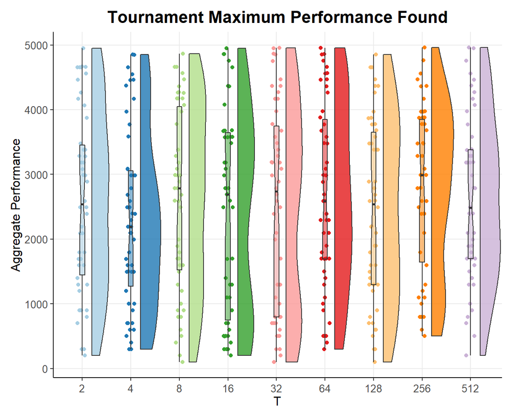

### 3.1.1 Summary Statistics

```r
# GET STATS BETWEEN EACH T
do.call("rbind", tapply(max_perf$val, max_perf$T, summary))
```

```
##        Min.   1st Qu.   Median     Mean  3rd Qu.    Max.
## 2   199.998 1447.2200 2540.855 2594.314 3451.372 4946.88
## 4   299.979 1273.0875 2191.975 2301.396 3055.832 4852.65
## 8   100.000 1521.8975 2788.140 2637.434 4046.673 4864.19
## 16  199.995  749.5850 2691.905 2419.856 3646.673 4947.88
## 32  100.000  799.3365 2737.585 2495.274 3750.205 4952.52
## 64  299.937 1695.1000 2589.685 2672.459 3851.460 4955.86
## 128 100.000 1297.9650 2540.770 2458.457 3654.253 4855.93
## 256 499.940 1647.4675 2988.200 2779.102 3850.273 4958.87
## 512 199.994 1696.0750 2487.765 2626.165 3383.012 4960.62
```

### 3.1.2 Stats Tests

The Kuskal-Wallis test show evidence of no statisticaly significant differences between tournament sizes.

```r
kruskal.test(val ~ T, data = max_perf)
```

```
##
##  Kruskal-Wallis rank sum test
##
## data:  val by T
## Kruskal-Wallis chi-squared = 4.6896, df = 8, p-value = 0.7902
```

The pairwaise Wilcoxon rank sum tests show evidence of no statisticaly significant differences between tournament sizes.

```r
pairwise.wilcox.test(x = max_perf$val, g = max_perf$T, p.adjust.method = "BH", paired = FALSE, conf.int = TRUE, conf.level = .95, alternative = 't')
```

```
##
##  Pairwise comparisons using Wilcoxon rank sum test
##
## data:  max_perf$val and max_perf$T
##
##     2    4    8    16   32   64   128  256
## 4   0.96 -    -    -    -    -    -    -
## 8   0.96 0.96 -    -    -    -    -    -
## 16  0.96 0.96 0.96 -    -    -    -    -
## 32  0.96 0.96 0.96 0.96 -    -    -    -
## 64  0.96 0.96 0.96 0.96 0.96 -    -    -
## 128 0.96 0.96 0.96 0.96 0.97 0.96 -    -
## 256 0.96 0.96 0.96 0.96 0.96 0.96 0.96 -
## 512 0.96 0.96 0.98 0.96 0.96 0.96 0.96 0.96
##
## P value adjustment method: BH
```

## 3.2 Maximum Optimal Objective Count Data

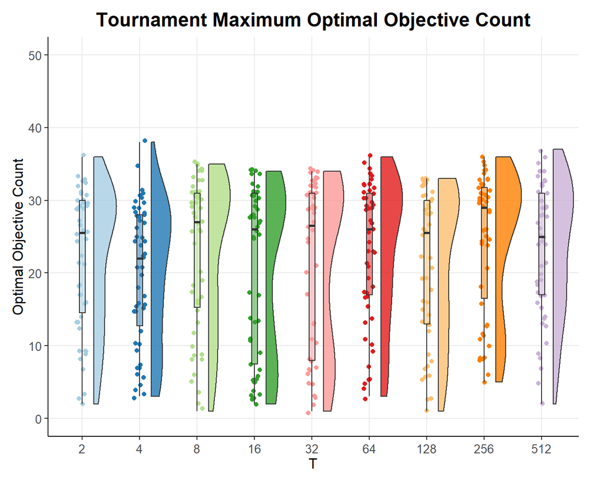

### 3.2.1 Summary Statistics

```r
# GET STATS BETWEEN EACH T
do.call("rbind", tapply(max_opti$val, max_opti$T, summary))
```

```
##     Min. 1st Qu. Median  Mean 3rd Qu. Max.
## 2      2   14.50   25.5 21.98   30.00   36
## 4      3   12.75   22.0 20.02   28.00   38
## 8      1   15.25   27.0 22.84   31.00   35
## 16     2    7.50   26.0 20.50   31.00   34
## 32     1    8.00   26.5 21.24   31.00   34
## 64     3   17.00   26.0 22.80   31.00   36
## 128    1   13.00   25.5 21.36   30.00   33
## 256    5   16.50   29.0 24.46   31.75   36
## 512    2   17.00   25.0 23.34   31.00   37
```

### 3.2.2 Stats Tests

The Kuskal-Wallis test shows no evidence of statisticaly significant differences between tournament sizes.

```r
kruskal.test(val ~ T, data = max_opti)
```

```
##
##  Kruskal-Wallis rank sum test
##
## data:  val by T
## Kruskal-Wallis chi-squared = 9.9502, df = 8, p-value = 0.2685
```

The pairwaise Wilcoxon rank sum tests show evidence of no statisticaly significant differences between tournament sizes.

```r
pairwise.wilcox.test(x = max_opti$val, g = max_opti$T, p.adjust.method = "BH", paired = FALSE, conf.int = TRUE, conf.level = .95, alternative = 't')
```

```
##
##  Pairwise comparisons using Wilcoxon rank sum test
##
## data:  max_opti$val and max_opti$T
##
##     2    4    8    16   32   64   128  256
## 4   0.75 -    -    -    -    -    -    -
## 8   0.75 0.56 -    -    -    -    -    -
## 16  0.90 0.75 0.75 -    -    -    -    -
## 32  0.91 0.75 0.75 0.75 -    -    -    -
## 64  0.75 0.56 0.91 0.75 0.90 -    -    -
## 128 0.95 0.75 0.75 0.90 0.90 0.75 -    -
## 256 0.56 0.17 0.75 0.56 0.75 0.75 0.56 -
## 512 0.75 0.56 0.99 0.75 0.75 0.91 0.75 0.75
##
## P value adjustment method: BH
```

# 4 Epsilon Lexicase Selection

## 4.1 Maximum Aggregate Performance Data

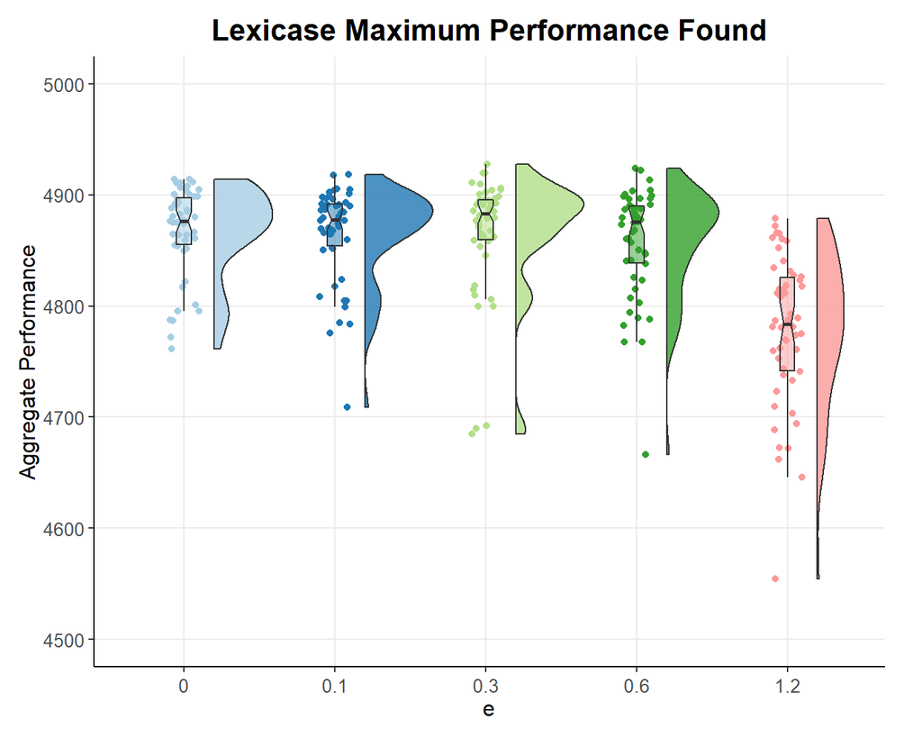

### 4.1.1 Summary Statistics

```r
# GET STATS BETWEEN EACH e
do.call("rbind", tapply(max_perf$val, max_perf$e, summary))
```

```
##        Min.  1st Qu.   Median     Mean  3rd Qu.    Max.
## 0   4761.60 4855.712 4876.610 4867.926 4897.698 4914.09
## 0.1 4708.65 4854.007 4877.790 4865.128 4891.970 4918.77
## 0.3 4684.75 4859.583 4883.045 4865.492 4895.592 4927.69
## 0.6 4666.00 4838.958 4875.575 4857.547 4889.852 4924.01
## 1.2 4554.17 4741.618 4784.020 4777.975 4825.788 4878.63
```

### 4.1.2 Stats Tests

The Kuskal-Wallis test show evidence of statisticaly significant differences between espilon values.

```r
kruskal.test(val ~ e, data = max_perf)
```

```
##
##  Kruskal-Wallis rank sum test
##
## data:  val by e
## Kruskal-Wallis chi-squared = 70.327, df = 4, p-value = 1.936e-14
```

```r
pairwise.wilcox.test(x = max_perf$val, g = max_perf$e, p.adjust.method = "BH", paired = FALSE, conf.int = TRUE, conf.level = .95, alternative = 't')
```

```
##
##  Pairwise comparisons using Wilcoxon rank sum test
##
## data:  max_perf$val and max_perf$e
##
##     0       0.1     0.3     0.6
## 0.1 0.79    -       -       -
## 0.3 0.79    0.54    -       -
## 0.6 0.48    0.54    0.28    -
## 1.2 1.2e-10 1.6e-10 1.9e-10 2.5e-09
##
## P value adjustment method: BH
```

## 4.2 Maximum Optimal Objective Count Data

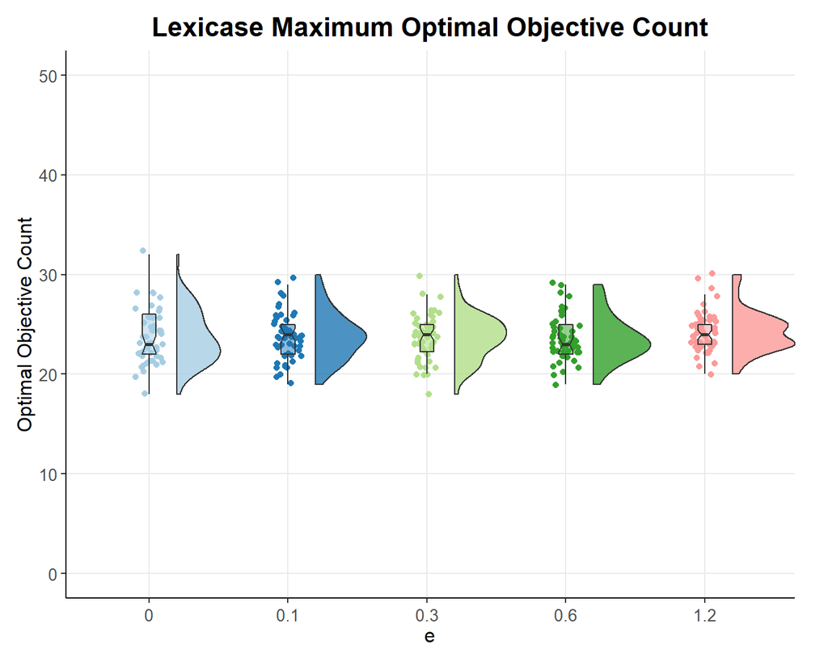

### 4.2.1 Summary Statistics

```r
# GET STATS BETWEEN EACH e
do.call("rbind", tapply(max_opti$val, max_opti$e, summary))
```

```
##     Min. 1st Qu. Median  Mean 3rd Qu. Max.
## 0     18   22.00     23 23.72      26   32
## 0.1   19   22.00     24 23.80      25   30
## 0.3   18   22.25     24 23.72      25   30
## 0.6   19   22.00     23 23.60      25   29
## 1.2   20   23.00     24 24.28      25   30
```

### 4.2.2 Stats Tests

The Kuskal-Wallis test show no evidence of statisticaly significant differences between epsilon values.

```r
kruskal.test(val ~ e, data = max_opti)
```

```
##
##  Kruskal-Wallis rank sum test
##
## data:  val by e
## Kruskal-Wallis chi-squared = 3.1452, df = 4, p-value = 0.5338
```

The pairwaise Wilcoxon rank sum tests show evidence that there is no statistic significant difference between epsilon values.

```r
pairwise.wilcox.test(x = max_opti$val, g = max_opti$e, p.adjust.method = "BH", paired = FALSE, conf.int = TRUE, conf.level = .95, alternative = 't')
```

```
##
##  Pairwise comparisons using Wilcoxon rank sum test
##
## data:  max_opti$val and max_opti$e
##
##     0    0.1  0.3  0.6
## 0.1 0.93 -    -    -
## 0.3 0.93 0.99 -    -
## 0.6 0.99 0.93 0.93 -
## 1.2 0.81 0.90 0.90 0.81
##
## P value adjustment method: BH
```